# Expressão diferencial de genes com dados de RNA-Seq

Minicurso online · 2 encontros de 4 h

## Objetivos

Ao final, você deve conseguir:

1. Explicar como a matriz de contagens é gerada e o que fica “gravado” nela
2. Distinguir replicatas técnicas de biológicas e mostrar, por simulação, por que só as biológicas sustentam inferência
3. Reconhecer desenhos balanceados, desbalanceados e confundidos
4. Escolher e defender um método de normalização
5. Comparar edgeR, DESeq2 e limma-voom e interpretar divergências
6. Planejar análises com mistura de experimentos e sem genoma de referência

## Onde a análise de DE se encaixa

- A análise de expressão diferencial (DGE) está entre as aplicações mais usadas de RNA-Seq, com papel central na busca por biomarcadores e alvos terapêuticos (Rosati et al., 2024)
- O pipeline revisado pelos autores vai do pré-processamento à lista de DEGs, seguida de enriquecimento funcional, redes e priorização de biomarcadores

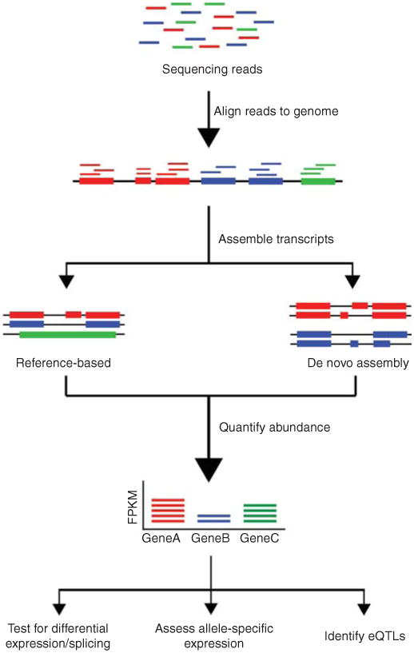

## Agenda

- Bloco 1 · Da amostra à matriz de contagens
- Bloco 2 · Replicatas técnicas vs biológicas
- Bloco 3 · Desenhos balanceados, desbalanceados e confundidos
- Bloco 4 · QC, filtragem e normalização

**As decisões**

- Bloco 5 · Modelos para definir DEGs
- Bloco 6 · Mistura de experimentos e lotes
- Bloco 7 · Sem genoma de referência
- Desafio final em equipes

## Bloco 1 · Da amostra à matriz de contagens

## A matriz de contagens não é “a expressão do gene”

É o resultado de uma cadeia de decisões. Cada uma deixa uma marca que a estatística não apaga.

## Decisões de bancada e de sequenciamento

| Etapa | Decisão | O que muda nas contagens |
| --- | --- | --- |
| Coleta / extração | Dia, operador, qualidade do RNA (RIN) | Possível efeito de lote |
| Biblioteca | Poli-A vs depleção de rRNA; stranded | Quais RNAs aparecem; perfil de cobertura |
| Sequenciamento | Single-end vs paired-end; profundidade | Precisão para genes pouco expressos |
| Processamento | Alinhamento (STAR, HISAT2) ou pseudoalinhamento (Salmon, kallisto) | Atribuição de reads ambíguas |

Mais replicatas costumam valer mais que mais profundidade para DE em nível de gene.

## Do FASTQ às contagens

**Com genoma de referência**

- Índice do genoma → alinhamento → contagem por gene (featureCounts, HTSeq)
- Detalhado no capítulo 2 do material do X-meeting 2026

**Com transcriptoma**

- Pseudoalinhamento (Salmon, kallisto) → agregação por gene (tximport) (Ver no site - Mapeamento e contagem)

## O que entra no teste de DE

- **Contagens brutas inteiras** por gene × amostra — é o que edgeR, DESeq2 e limma-voom esperam
- RPKM, FPKM e TPM corrigem o comprimento do gene: servem para comparar genes **dentro** de uma amostra
- Eles **não** substituem a normalização usada no teste de DE

[figure not shown]

## Enquete relâmpago

> Seu laboratório sequenciou 3 controles em março e 3 tratados em agosto, com o mesmo kit. Qual o principal risco?
1. Profundidade diferente
2. Efeito de lote confundido com o tratamento
3. Genes curtos sub-representados

## Bloco 2 · Replicatas técnicas vs biológicas

## Duas fontes de variação

**Replicata técnica**

- A mesma amostra sequenciada mais de uma vez
- Mede o ruído da medição
- Variância ≈ média (Poisson)

**Replicata biológica**

- Indivíduos, culturas ou plantas independentes
- Soma a variação biológica
- Variância cresce mais rápido que a média

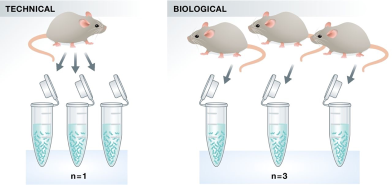

## Por que binomial negativa

\[\text{Var}(Y) = \mu + \phi\,\mu^2 \qquad \text{BCV} = \sqrt{\phi}\]

- \(\phi\) = dispersão biológica; \(\phi = 0\) volta à Poisson
- Valores típicos de BCV: ~0,1 em linhagens celulares; 0,4 ou mais em populações humanas

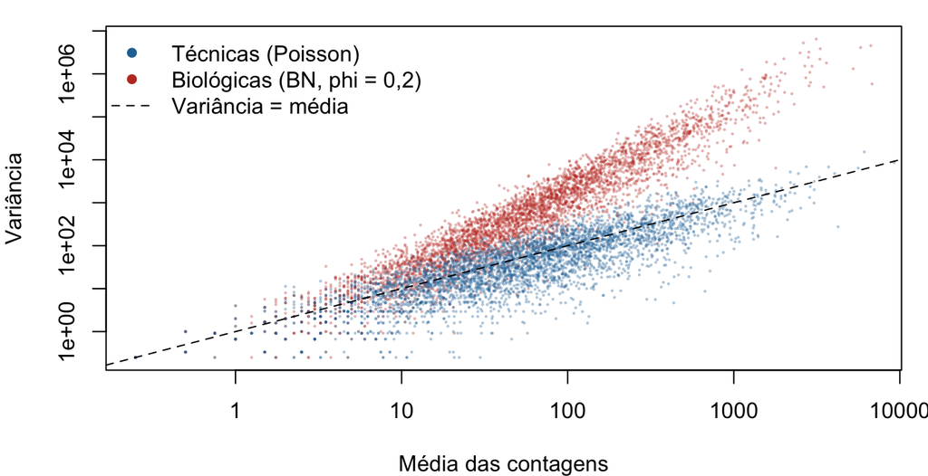

## O que fazer com cada tipo

- **Técnicas:** somar por amostra biológica antes da análise
  - `edgeR::sumTechReps()` ou `DESeq2::collapseReplicates()`
- **Biológicas:** são as unidades da inferência
- **Pool de RNA:** reduz custo, mas o pool vira **uma** replicata e esconde a variação individual

Duplas · semente = 100 + número da dupla

```r
library(edgeR)
counts <- matrix(c(
  120,135,110,540,580,510,
  800,820,790,810,795,825,
   50, 45, 55, 12, 10, 14,
  300,290,310,305,295,315,
   20, 18, 22, 95,100, 88,
 1000,980,1020,990,1010,1000
), nrow=6, byrow=TRUE,
   dimnames=list(c("GeneA","GeneB","GeneC","GeneD","GeneE","GeneF"),
                c("CTRL_1","CTRL_2","CTRL_3","TREAT_1","TREAT_2","TREAT_3")))
group <- factor(c("CTRL","CTRL","CTRL","TREAT","TREAT","TREAT"))
```

**Antes de rodar:** quantos “DEGs” você espera em cada cenário?

## Bloco 3 · Desenho experimental

## Balanceado, desbalanceado, confundido

- **Desbalanceado** custa poder, mas os GLMs lidam bem com ele
- **Confundido** não tem conserto na análise — só no desenho

## Como checar em R

```r
d <- data.frame(condicao = rep(c("Ctrl", "Trat"), each = 4),
                lote     = rep(c("L1", "L2"), each = 4))
table(d$condicao, d$lote)
X <- model.matrix(~ lote + condicao, data = d)
qr(X)$rank < ncol(X)   # TRUE = confundido
```

| Desenho | Posto / colunas | Diagnóstico |
| --- | --- | --- |
| Confundido | 2 / 3 | Efeito do tratamento não estimável |
| Balanceado | 3 / 3 | Estimável |
| Parcial (5 vs 3) | 3 / 3 | Estimável; lote entra no modelo |

## Quantas replicatas?

- Menos de 3 por grupo: dispersão mal estimada
- 6 ou mais: ganho grande de poder para efeitos moderados
- Calcule antes de sequenciar: RNASeqPower, PROPER, ssizeRNA

## Prática 2 · O custo do desbalanceamento

Duplas · 30 min · Parte A: diagnóstico do desenho · Parte B: simulação com verdade conhecida

12 amostras, 10% dos genes realmente diferenciais (FC = 2), \(\phi\) = 0,2:

| Desenho | DEGs | Sensibilidade (TPR) | FDR observado |
| --- | --- | --- | --- |
| 6 × 6 | 86 | 0,166 | 0,035 |
| 4 × 8 | 58 | 0,114 | 0,017 |
| 3 × 9 | 51 | 0,102 | 0,000 |
| 2 × 10 | 13 | 0,026 | 0,000 |
| 3 × 3 (só 6 amostras) | 12 | 0,024 | 0,000 |

Exemplo com semente 201. Cada dupla preenche sua linha no placar.

## Bloco 4 · QC, filtragem e normalização

## Profundidade e composição

- **Profundidade:** 20 vs 40 milhões de reads → CPM resolve
- **Composição:** poucos genes muito expressos “roubam” reads dos demais, que parecem cair sem ter mudado
- TMM (edgeR) e mediana das razões/RLE (DESeq2) corrigem composição assumindo que **a maioria dos genes não muda**

## Demonstração · 10 genes, só 1 muda

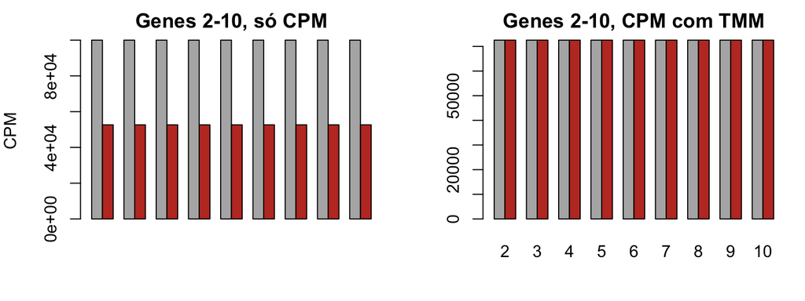

```r
library(edgeR)
toy <- cbind(A = rep(100, 10), B = c(1000, rep(100, 9)))
cpm_bruto <- cpm(toy)
cpm_tmm   <- cpm(calcNormFactors(DGEList(toy)))
par(mfrow = c(1, 2), mar = c(4, 4, 2, 1))
barplot(t(cpm_bruto[2:10, ]), beside = TRUE, main = "Genes 2-10, só CPM",
        col = c("grey70", "#C0392B"), ylab = "CPM")
barplot(t(cpm_tmm[2:10, ]), beside = TRUE, main = "Genes 2-10, CPM com TMM",
        col = c("grey70", "#C0392B"))
```

## Métodos de normalização

| Método | Onde | Ideia | Observação |
| --- | --- | --- | --- |
| TMM / TMMwsp | edgeR | Média aparada dos log-ratios contra uma amostra de referência | Padrão do edgeR; TMMwsp para muitos zeros |
| RLE / mediana das razões | edgeR, DESeq2 | Mediana da razão contra a média geométrica | Padrão do DESeq2 |
| Quartil superior | edgeR | Escala pelo 75º percentil | Menos usado |
| TPM / FPKM | — | Comprimento + profundidade | Não usar como entrada do teste |

**Quando a premissa falha:** mudanças globais de transcrição → spike-ins (ERCC) ou genes de controle.

## Explorar antes de testar

- Tamanho das bibliotecas
- Filtragem: `filterByExpr()` usa o menor grupo para definir o corte
- Boxplot de logCPM antes/depois
- Gráfico MD (diferença × média)
- MDS / PCA: as amostras se agrupam pela condição?

## Prática 3 · Normalizações no dado do X-meeting

Duplas · 30 min · gse95077 (3 BM × 3 JJ) · cada dupla sorteia um método

```r
url <- "https://github.com/costasilvati/x-meeting2026_rnaseq/raw/main/data/gse95077.rda"
download.file(url, "gse95077.rda", mode = "wb"); load("gse95077.rda")
counts <- as.matrix(gse95077); grupo <- factor(rep(c("BM", "JJ"), each = 3))
y <- DGEList(counts, group = grupo)
y <- y[filterByExpr(y), , keep.lib.sizes = FALSE]
sapply(c("none", "TMM", "TMMwsp", "RLE", "upperquartile"),
       function(m) calcNormFactors(y, method = m)$samples$norm.factors)
```

## Prática 3 · O que o dado mostra

| Método | DEGs (FDR < 0,05) |
| --- | --- |
| none | 23 |
| TMM | 22 |
| TMMwsp | 23 |
| RLE | 23 |
| upperquartile | 21 |

**Pegadinha para discussão:** a matriz tem só **31 genes**, já pré-selecionados, e cerca de 22 deles são DE.

A premissa “a maioria dos genes não muda” vale aqui?

## Síntese do encontro 1

1. Só replicatas **biológicas** sustentam inferência sobre a condição
2. Desbalanceamento custa **poder**; confundimento custa **a pergunta**
3. Normalização para DE corrige **composição**, não só profundidade

**Tarefa (15 min):** descreva um experimento real em até 5 linhas — organismo, condições, nº de replicatas, lotes, genoma de referência.

## Encontro 2 · As decisões

## Bloco 5 · Modelos para definir DEGs

## Os métodos concordam no centro e divergem na margem

- A revisão de Rosati et al. (2024) apresenta DESeq2, edgeR e limma como as ferramentas centrais, ao lado de alternativas como NOISeq, baySeq e DEGseq, discutindo vantagens e limitações de cada uma

## Comparando os modelos

| Método | Modelo e teste | Quando faz mais sentido |
| --- | --- | --- |
| edgeR `exactTest` | Binomial negativa, teste exato; 2 grupos | Comparação simples (material do X-meeting) |
| edgeR QL (`glmQLFit`) | GLM BN + incerteza da dispersão | Covariáveis (lote, pareamento); mais conservador |
| DESeq2 (Wald / LRT) | GLM BN, dispersão encolhida | Uso geral; LRT para fatores com vários níveis |
| limma-voom | Modelo linear em logCPM com pesos | Muitas amostras; desenhos complexos; rápido |
| NOISeq | Não paramétrico (estatísticas M e D vs ruído) | Poucas ou nenhuma replicata; exploração |

## Dispersão: emprestar informação entre genes

- Com 3 replicatas, a variância de cada gene sozinho é ruim
- Todos os métodos encolhem (empirical Bayes) a estimativa de cada gene em direção a uma tendência
- edgeR: dispersão comum → trended → tagwise (capítulo 3 do material do X-meeting)

## FDR não é tamanho de efeito

- FDR < 0,05 diz que a mudança provavelmente **não é zero**, não que é grande
- Para exigir efeito mínimo, **teste** contra um limiar em vez de filtrar logFC depois:
  - edgeR `glmTreat()` · DESeq2 `results(..., lfcThreshold = 1)` · limma `treat()`
- `lfcShrink()` (DESeq2) reduz fold changes exagerados de genes pouco expressos: use para ranquear e visualizar

## Prática 4 · Três métodos, um dado

Duplas · 25 min · piloto: edgeR e voom · navegadora: DESeq2

```r
design <- model.matrix(~ grupo)
fit <- glmQLFit(estimateDisp(y, design), design)          # edgeR QL
res_edger <- topTags(glmQLFTest(fit, coef = 2), n = Inf)$table
res_voom  <- topTable(eBayes(lmFit(voom(y, design), design)), coef = 2, n = Inf)
coldata <- data.frame(grupo = grupo, row.names = colnames(counts))
dds <- DESeq(DESeqDataSetFromMatrix(round(counts), coldata, ~ grupo))
res_deseq <- results(dds, alpha = 0.05)
res_treat <- topTags(glmTreat(fit, coef = 2, lfc = 1), n = Inf)$table
```

No gse95077: 22 DEGs em cada método, 21 em comum, 7 com |log2FC| > 1 testado.

## Bloco 6 · Mistura de experimentos

## Juntar dados só ajuda se o desenho permitir

- Tipos de mistura: lotes de sequenciamento · protocolos (SE/PE, poli-A/rRNA) · estudos públicos · amostras pareadas
- **Antes de juntar:** reprocessar tudo dos FASTQ com o mesmo pipeline, genoma e anotação
- Cada lote/estudo precisa conter **mais de uma condição**

## Estratégias

| Situação | Estratégia |
| --- | --- |
| Lote conhecido | `~ lote + condicao` |
| Amostras pareadas | `~ individuo + condicao` |
| Lote desconhecido | Fatores ocultos com `sva` (svaseq) ou `RUVSeq` como covariáveis |
| Visualização | `limma::removeBatchEffect()` — **só** para PCA e heatmap |
| Contagens ajustadas | ComBat-seq existe, mas o lote no modelo é preferível para DE |
| Lote = condição | Não juntar: análise por estudo + meta-análise |

## Prática 5 · pasilla: SE e PE misturados

Duplas · 25 min · *Drosophila*, tratado vs não tratado, desenho desbalanceado

```r
table(coldata$condition, coldata$type)          # balanceado? cruzado?
plotMDS(y, col = as.numeric(coldata$type))      # o protocolo aparece?
res_ingenuo <- roda(~ condition)
res_lote    <- roda(~ type + condition)
```

## Bloco 7 · Sem genoma de referência

## Você constrói a unidade de análise

- Alternativa: genoma de espécie próxima com alinhamento tolerante — confira a taxa de alinhamento

## Limitações que você deve reportar

- Contigs redundantes: isoformas, fragmentos, alelos
- Quimeras de montagem
- Parálogos colapsados num único contig
- Anotação por homologia que pode errar a função
- Muitos DEGs sem anotação — é resultado, não erro

## Prática 6 · Contig ou gene?

Duplas · 25 min · transcriptoma Trinity simulado, verdade conhecida

| Nível | Testes | Genes DE recuperados |
| --- | --- | --- |
| Contig | 7 086 | 3,5% |
| Gene (agregado) | 2 000 | 21,5% |

Exemplo com semente 301.

```r
gene <- rowsum(tx, gene_id)                                     # simulação: agrega contigs
txi  <- tximport(files, type = "salmon", tx2gene = tx2gene)     # caminho real com Salmon
```

## Desafio final

## Estudos de caso em equipe

| Caso | Cenário | Armadilha |
| --- | --- | --- |
| A | Seca vs controle, 2 vs 2; uma amostra re-sequenciada aparece duas vezes | Técnica como biológica; n mínimo |
| B | 3 estudos do GEO com condições distribuídas de forma desigual | Lote confundido; reprocessar ou meta-análise |
| C | Peixe nativo sem genoma, 5 vs 5, Trinity com 180 mil contigs | Agregação, avaliação, anotação |
| D | 25 tumores vs 6 normais, 3 lotes; normais todos no lote 3 | Desbalanceamento + confundimento parcial |

55 min de trabalho · 3 min de apresentação por equipe · 1 pergunta de outra equipe

## Depois da lista de DEGs

Rosati et al. (2024) mostram que a lista de DEGs é o ponto de partida para:

- Enriquecimento funcional: GO, KEGG, Reactome (DAVID, GSEA, GSVA, topGO)
- Redes de interação e coexpressão: STRING, Cytoscape, WGCNA
- Priorização de biomarcadores e alvos terapêuticos

Tudo isso herda as limitações do desenho e da análise de DE.

## Checklist: o que devo saber

- Minhas replicatas são biológicas? Somei as técnicas?
- Tenho ≥ 3 replicatas por grupo?
- Cada lote/estudo contém mais de uma condição? Conferi o posto da matriz de desenho?
- Usei contagens brutas como entrada?
- A premissa “a maioria não muda” vale para o meu experimento?
- O MDS separa as amostras pela condição?
- Método e fórmula combinam com o desenho?
- Reportei FDR **e** efeito mínimo testado?
- Sem genoma: avaliei a montagem e analisei em nível de gene?
- Escrevi as limitações?

## Referências e materiais

- Rosati D, Palmieri M, Brunelli G, Morrione A, Iannelli F, Frullanti E, Giordano A. Differential gene expression analysis pipelines and bioinformatic tools for the identification of specific biomarkers: a review. *Computational and Structural Biotechnology Journal*, 23:1154–1168, 2024. doi:10.1016/j.csbj.2024.02.018
- Costa-Silva J, Lopes FM. *Expressão diferencial de genes com dados de RNA-Seq utilizando a linguagem R*. Material do X-meeting 2026. https://costasilvati.github.io/x-meeting2026_rnaseq/
- Tutoriais comparativos edgeR, DESeq2 e NOISeq: https://costasilvati.github.io/x-meeting2026_rnaseq/compare/comparacao_DE.html
- Pacotes Bioconductor: edgeR, DESeq2, limma, pasilla, tximport
- Dados: gse95077 (repositório do X-meeting e pacote consexpressionR)